# NLP - Data Exploration

Claus Bo Hansen

November 27, 2019

**Week 2 Milestone report in capstone project in the Data Science Specialization on Johns Hopkins.**

# 1 Abstract

## 1.1 Purpose

The purpose of this exploration phase is to understand what is in the datasets.  
Three datasets (types of content) are provided:

1. Blog
2. News
3. Twitter

## 1.2 Observations

- All content types has a very large amount of words, which only occur very few times
- By requiring a word to occur 50 times (approximately 0.005% of documents) the number of terms can be reduced with around 98%
- “The” is bar far the most common word in all three content types

## 1.3 Ideas for prediction application

- Terms which only occur rarely in the data can be removed. This will greatly reduce the size of the dataset, which I expect to increase (speed) performance
- Document Term Matrices must be built for uni-, bi, tri- and quadgrams in order to be able to predict based on previous 1, 2 or 3 words
- Bi-, tri-, and quadgram can be reduced in the same way as unigrams, i.e. remove rare entries

# 2 Data Exploration

Term frequency histograms are plotted both for the entire Corpus and for terms on occuring 50 times or more.

## 2.1 blogs

Number of strings in set: 899,288

### 2.1.1 Top 10 terms

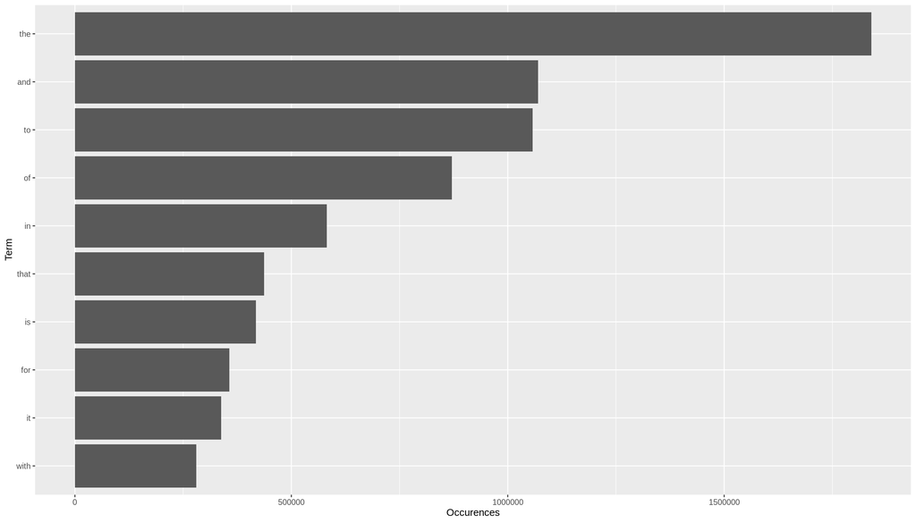

### 2.1.2 Word densities

**All**

Number of unique words (unigrams) in set: 964,184

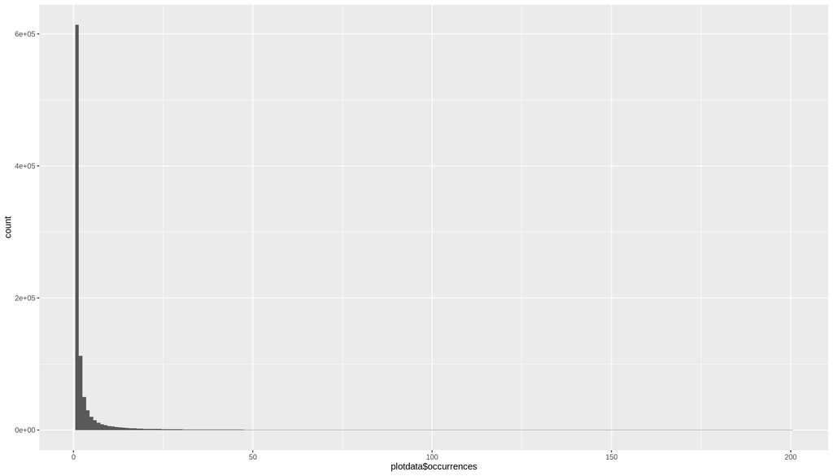

**Above50**

Number of unique words (unigrams) in set: 24,413

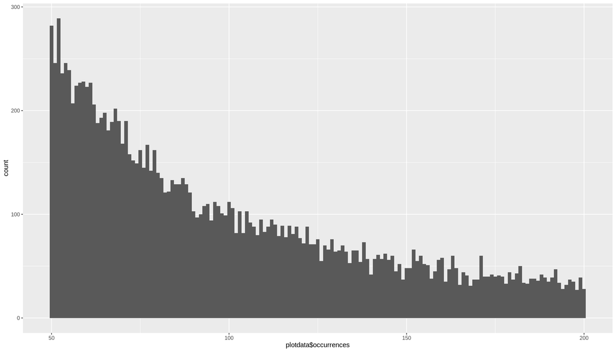

## 2.2 news

Number of strings in set: 1,010,242

### 2.2.1 Top 10 terms

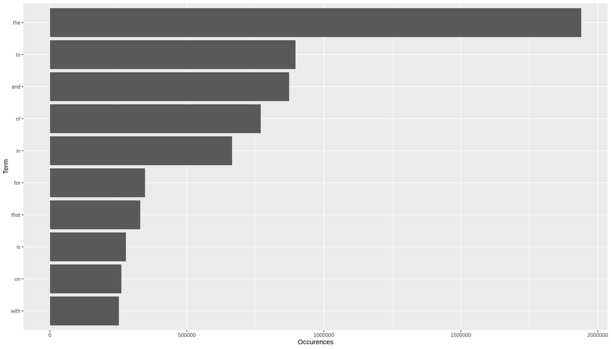

### 2.2.2 Word densities

**All**

Number of unique words (unigrams) in set: 790,131

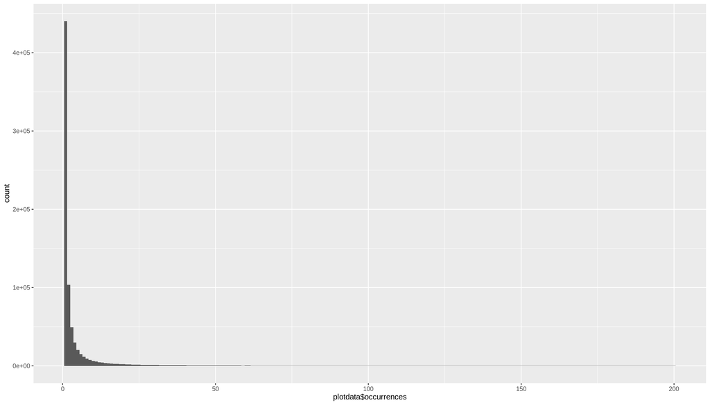

**Above50**

Number of unique words (unigrams) in set: 25,558

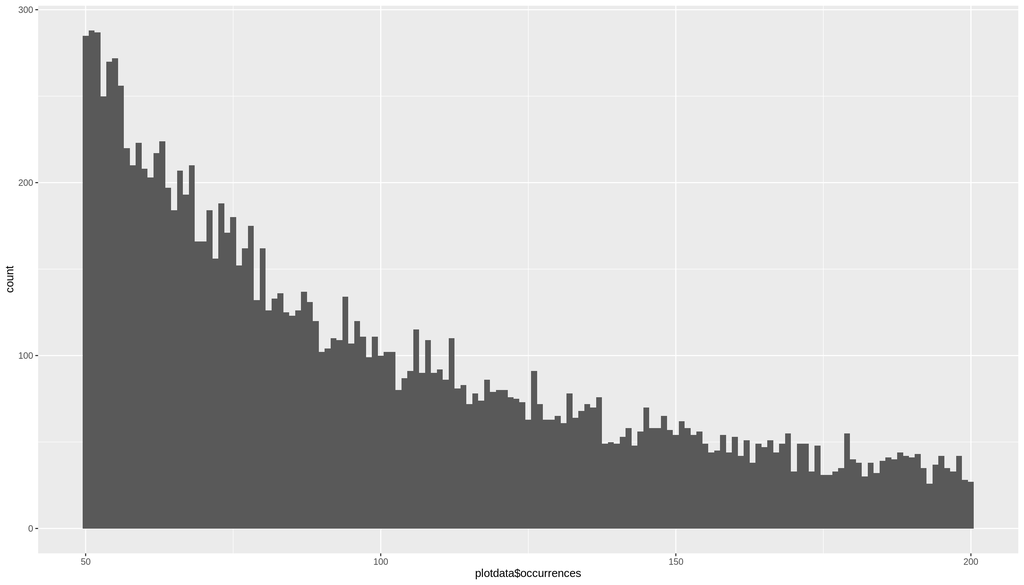

## 2.3 twitter

Number of strings in set: 2,360,148

### 2.3.1 Top 10 terms

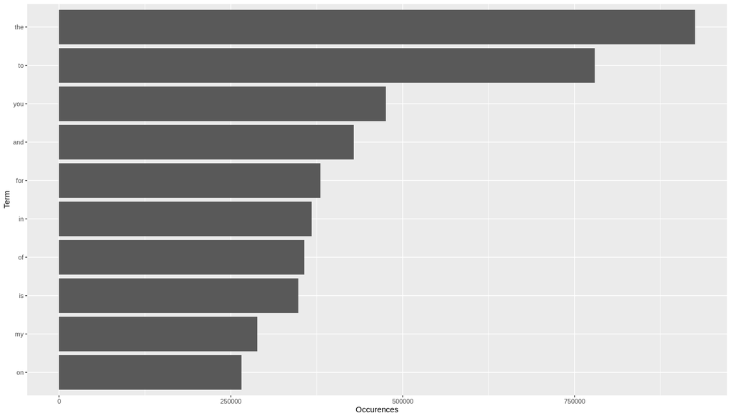

### 2.3.2 Word densities

**All**

Number of unique words (unigrams) in set: 1,079,530

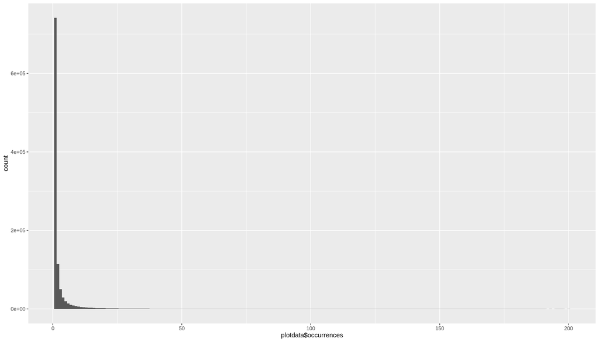

**Above50**

Number of unique words (unigrams) in set: 18,227

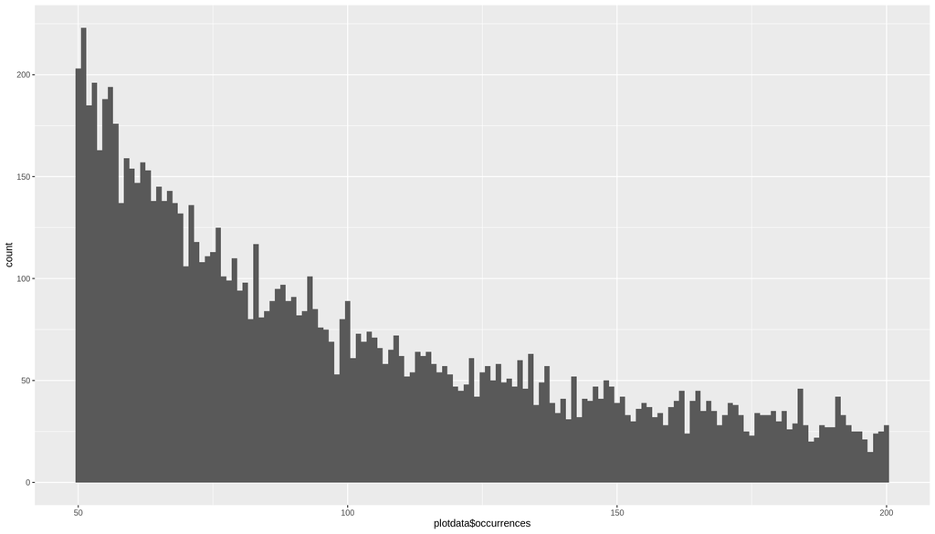

## 2.4 Summary of tables

```
  Dataset   Lines UniqueWords UniqueWordsOccuring50timesOrMore
1   blogs  899288      964184                            24413
2    news 1010242      790131                            25558
3 twitter 2360148     1079530                            18227
```